# Data validation and editing

Statistical Programming with R

## Packages and functions used

```r
library(lubridate)
library(stringi)
library(stringr)
library(stringdist)
library(editrules)
library(deducorrect)
library(rex)
```

## Resources:

By Edwin de Jonge & Mark van der Loo:

### Statistical Data Cleaning with Applications in R:

Comprehensive book

### An introduction to data cleaning with R:

Shorter working paper, available online

## Statistical value chain

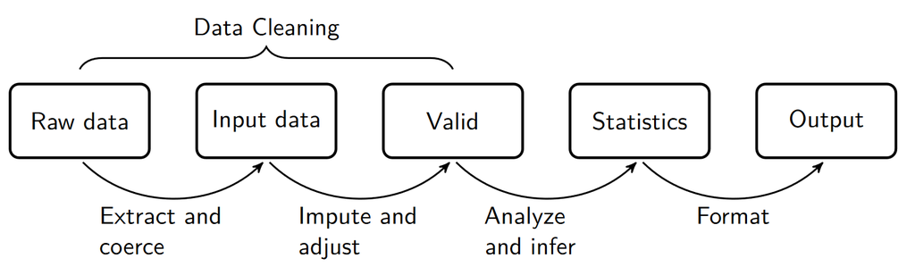

- A way to think about the process of producing statistics and separating production systems
- By this logic, you should store the data for each state separately for reuse, and probably also use separate R scripts for each step
- For reproducibility!

## Concepts

### Technically correct data

- Well-defined format (data structure)
- Well-defined types (numbers, date/time,string, categorical\(...\) )
- Statistical units can be identified (persons, transactions, phone calls\(...\))
- Variables can be identified as properties of statistical units.

### Consistent data

- Data satisfies demands from domain knowledge
- Ready for analysis

## Some basics

## Variable types in R:

- `numeric`
- `integer`
- `factor` - categorical data
- `ordered` - ordinal data
- `character` - character data
- `logical` - `TRUE` or `FALSE`
- `raw` - binary data

## Special values

- `NA`: Not available - placeholder for a missing value. When computed with, returns `NA`
- `NULL`: The null object. Cannot be done maths on.
- `Inf`: Infinity - can be done maths on!
- `NaN`: *Not a Number*. Generally result of calculation (eg `Inf - Inf`). Is numeric, further computation always returns `NaN`

## Raw data to technically correct data

## Tabular data: long story short

- `read.table`: R’s swiss army knife
  - fairly strict (no sniffing)
  - Very flexible
  - Interface could be cleaner (see [this talk](http://sumsar.net/files/academia/UseR_2013_R_naming_conventions_final.pdf))
- `readr::read_csv`
  - Easy to switch between strict/lenient parsing
  - Compact control over column types
  - Fast
  - Clear reports of parsing failure

## For even dirtier data

- (base) R has great text processing tools.
- Need to work with regular expressions
- Write many small functions extracting single data elements.
- Don’t overgeneralize: adapt functions as you meet new input.

## Regular expressions

Express a *pattern* of text, e.g.

\[ \texttt{"(a|b)c*"} = \{\texttt{"a"},\texttt{"ac"},\texttt{"acc"},\ldots,\texttt{"b"},\texttt{"bc"},\texttt{"bcc"},\ldots\} \]

| **Task** | **stringr** | **Base R** |
| --- | --- | --- |
| string detection | str_detect(string, pattern) | grep, grepl |
| string extraction | str_extract(string, pattern) | regexpr, regmatches |
| string replacement | str_extract(string, pattern, replacement) | sub, gsub |
| string splitting | str_split(string, pattern) | strsplit |

## Tips on regular expressions with R

- `stringr` has *many* useful shorthands for common tasks.
- Generate regular expressions with `rex`

```r
library(rex)
# recognize a number in scientific notation
rex(one_or_more(digit)
    , maybe(".",one_or_more(digit))
    , "E" %or% "e"
    , one_or_more(digit))
```

```
## (?:[[:digit:]])+(?:\.(?:[[:digit:]])+)?(?:E|e)(?:[[:digit:]])+
```

## String normalization

Bring a text string in a standard format, e.g.

- Standardize upper/lower case (casefolding)
  - stringr: str_to_lower, str_to_upper, str_to_title
  - base R: tolower, toupper
- Remove accents (transliteration)
  - stringi: stri_trans_general
  - base R: iconv

## Approximate text matching

- Defines a distance metric between strings that measures how “different” two strings are.
- Uses this to correct data

```r
gender <- c("Male", "male", "Female", "fem.", "F", "M")
stringdist(gender, "Male")
```

```
## [1] 0 1 3 4 4 3
```

```r
stringdist(gender, "Female")
```

```
## [1] 3 2 0 4 5 6
```

## Approximate text matching

```r
gender <- c("Male", "male", "Female", "fem.", "F", "M")
codes <- c("male", "female")
D <- stringdistmatrix(gender, codes)
i <- apply(D, 1, which.min)
data.frame(rawtext = gender, coded = codes[i])
```

```
##   rawtext  coded
## 1    Male   male
## 2    male   male
## 3  Female female
## 4    fem. female
## 5       F   male
## 6       M   male
```

## Approximate text matching: edit-based distances

| *Distance* | *substitution* | *deletion* | *insertion* | *transposition* |
| --- | --- | --- | --- | --- |
| Hamming | yes | no | no | no |
| LCS | no | yes | yes | no |
| Levenshtein | yes | yes | yes | no |
| OSA | yes | yes | yes | yes |
| Damerau-Levenshtein | yes | yes | yes | yes |

\[\texttt{"leela"} \to \texttt{"leea"} \to \texttt{"leia"}\]

```r
stringdist::stringdist("leela","leia",method="dl")
```

```
## [1] 2
```

## Further steps in making data technically correct

- `lubridate`: extract dates from strings

  ```r
  lubridate::dmy("17 December 2015")
  ```

  ```
  ## [1] "2015-12-17"
  ```

- `tidyr`: many data cleaning operations to make your life easier
- `readr`: Parse numbers from text strings

  ```r
  readr::parse_number(c("2%","6%","0.3%"))
  ```

  ```
  ## [1] 2.0 6.0 0.3
  ```

## From technically correct to consistent data

## The mantra of data cleaning

- Detection (data conflicts with domain knowledge)
- Selection (find the value(s) that cause the violation)
- Correction (replace them with better values)

## Detection, AKA data validation

### Informally:

Data Validation is checking data against (multivariate) expectations about a data set

### For example

- Ages cannot be negative and should be less than 150 years
- The number of years married must be smaller than the age minus 17 years
- A person labeled as “single” should have the number of years married recorded as 0

### Validation rules

Often these expectations can be expressed as a set of simple *validation rules*.

The `validate` package allows us to define a set of validation rules which can then be applied to data

## The `validate` package, in summary

- Make data validation rules explicit
- Treat them as objects of computation
  - store to / read from file
  - manipulate
  - annotate
- Confront data with rules
- Analyze/visualize the results

## Use rules to correct data

### Main idea

Rules restrict the data. Sometimes this is enough to derive a correct value uniquely.

### Examples

- Correct typos in values under linear restrictions
  - \(123 + 45 \not= 177\), but \(123 + \underline{54} = 177\).
- Derive imputations from values under linear restrictions
  - \(123 + \texttt{NA} = 177\), compute \(177-123=54\).

Both can be generalized to systems \(\mathbf{Ax}\leq\mathbf{b}\).

The `deducorrect` package allows for deterministic imputation in these cases

## Selection, or: error localization

### Fellegi and Holt (1976)

Find the least (weighted) number of fields that can be imputed such that all rules can be satisfied.

### Note

- Solutions need not be unique.
- Random one chosen in case of degeneracy.
- Lowest weight need not guarantee smallest number of altered variables.

## Error localization

The `errorlocate` package

- For in-record rules
- Support for
  - linear (in)equality rules
  - Conditionals on categorical variables (if male then not pregnant)
  - Mixed conditionals (has job then age \(>= 15\))
  - Conditionals w/linear predicates (staff \(> 0\) then staff cost \(> 0\))
- Optimization is mapped to MIP problem.